# Лаьораторная работа №2

Задача о погоне

Разанацуа Сара Естэлл

Российский университет дружбы народов, Москва, Россия

## Цель работы

Построить математическую модель для выбора правильной стратегии при решении примера задаче о погоне.

## Задание

На море в тумане катер береговой охраны преследует лодку браконьеров. Через определенный промежуток времени туман рассеивается, и лодка обнаруживается на расстоянии 12,3 км от катера. Затем лодка снова скрывается в тумане и уходит прямолинейно в неизвестном направлении. Известно, что скорость катера в 4,4 раза больше скорости браконьерской лодки.

## Выполнение лабораторной работы

Формула для выбора варианта: `(1032225834%70)+1` = 25 вариант.

## Выполнение лабораторной работы

$$\dfrac{x}{v} = \dfrac{k-x}{4.4v} \text{ -- в первом случае}$$
$$\dfrac{x}{v} = \dfrac{k+x}{4.4v} \text{ -- во втором}$$

Отсюда мы найдем два значения x_1 = 2,277 и x_2 = 3,618, задачу будем решать для двух случаев.

## Выполнение лабораторной работы

$$v_{\tau} = \sqrt{19,36v^2-v^2} =
\sqrt{18,36}v$$

Из чего можно вывести:

$$r\dfrac{d \theta}{dt} = \sqrt{18,36}v$$

## Выполнение лабораторной работы

Решение исходной задачи сводится к решению системы из двух дифференциальных уравнений:

$$\begin{cases}
&\dfrac{dr}{dt} = v\\
&r\dfrac{d \theta}{dt} = \sqrt{18,36}v
\end{cases}$$

## Выполнение лабораторной работы

С начальными условиями для первого случая:

$$\begin{cases}
&{\theta}_0 = 0\\ \tag{1}
&r_0 = 2,277
\end{cases}$$

## Выполнение лабораторной работы

Или для второго:

$$\begin{cases}
&{\theta}_0 = -\pi\\ \tag{2}
&r_0 = 3,618
\end{cases}$$

## Выполнение лабораторной работы

Исключая из полученной системы производную по *t*, можно перейти к следующему уравнению:

$$\dfrac{dr}{d \theta} = \dfrac{r}{\sqrt{18,36}}$$

## Построение модели

- Построение модели

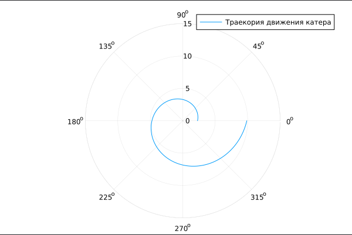

Траекория движения катера в 1 случае

## Построение модели

- Построение модели

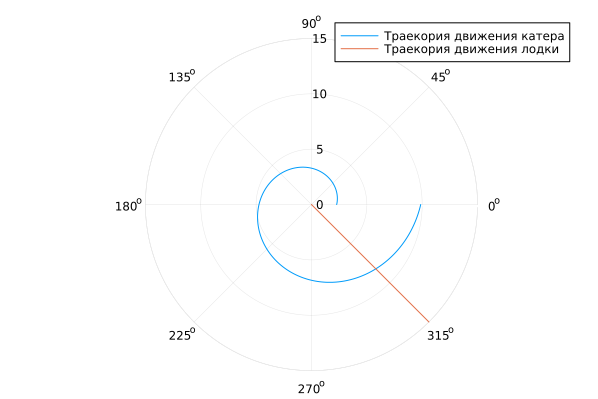

Траекория движения катера и лодки

## Построение модели в случае 2

- Построение модели

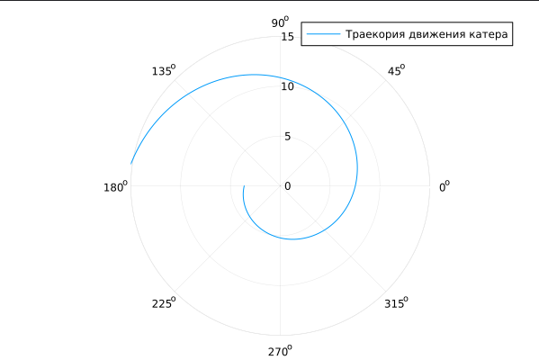

Траекория движения катера во 2 случае

## Построение модели в случае 2

- Построение модели

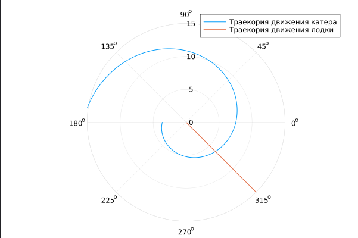

Траекория движения катера во 2 случае

## Выводы

В процессе выполнения данной лабораторной работы я построила математическую модель для выбора правильной стратегии при решении примера задаче о погоне.